# Proyecto1 Mineria de datos

# Analisis de todas las vairables

| Variable | Tipo de Variable |
| --- | --- |
| Id | Cualitativa nominal |
| Popularity | Cuantitativa continua |
| Budget | Cuantitativa continua |
| Revenue | Cuantitativa continua |
| Original_title | Cualitativa nominal |
| OriginalLanguage | Cualitativa nominal |
| Title | Cualitativa nominal |
| homePage | Cualitativa nominal |
| Video | Cualitativa nominal |
| director | Cualitativa nominal |
| rumtime | Cuantitativa continua |
| genres | Cualitativa nominal |
| genresAmount | Cuantitativa discreta |
| productionCompany | Cualitativa nominal |
| productionCompanyCountry | Cualitativa nominal |
| productionCoAmount | Cuantitativa discreta |
| productionCountry | Cualitativa nominal |
| productionContriesAmount | Cuantitativa discreta |
| releaseDate | Cualitativa ordinal |
| voteCount | Cuantitativa discreta |
| VoteAvg | Cuantitativa continua |
| actors | Cualitativa nominal |
| actorsPopularity | Cuantitativa continua |
| actorsCharacters | Cualitativa nominal |
| actorsAmount | Cuantitativa discreta |
| castWomenAmount | Cuantitativa discreta |
| castMenAmount | Cuantitativa discreta |

# Importacion de datos y librerias

Importamos las librerias

```python
import pandas as pd
import matplotlib.pyplot as plt
import seaborn as sns
from IPython.display import display
```

Aqui se cargan los datos

```python
df = pd.read_csv("movies_cleaned.csv")
```

# Analisis Variables Cuantitativas

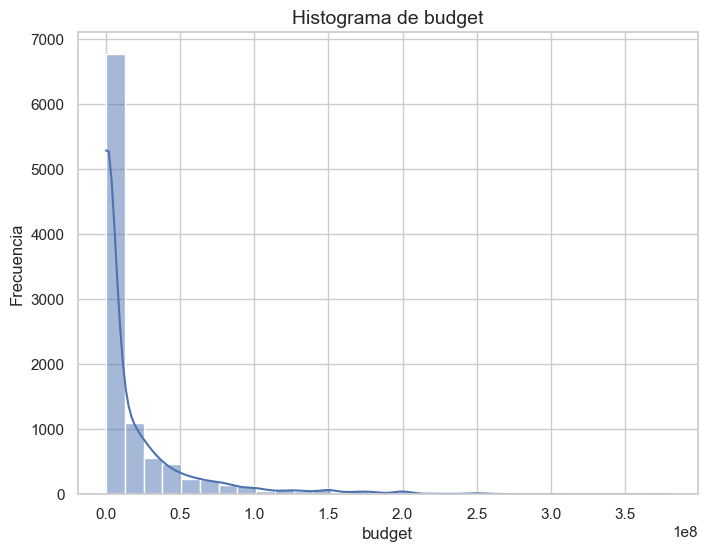

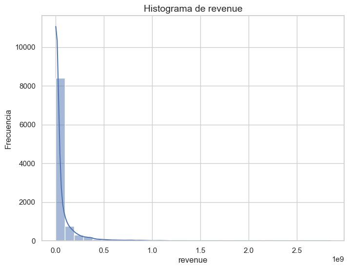

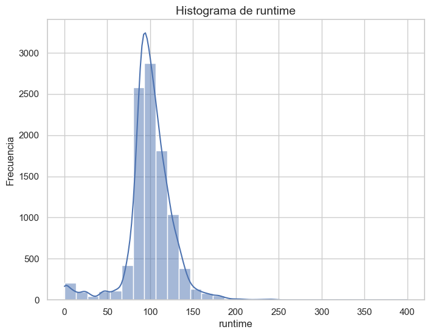

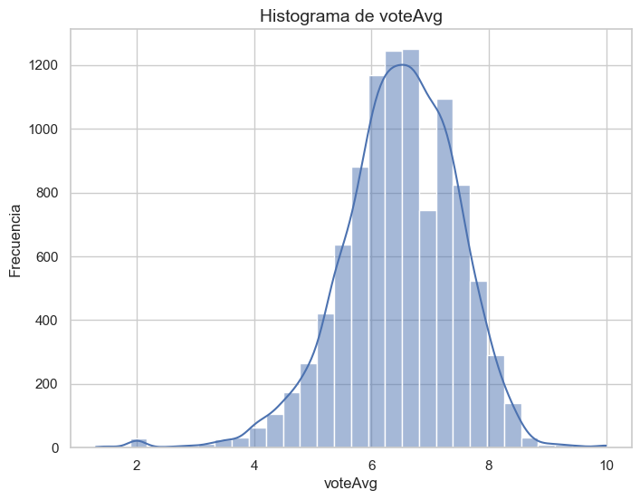

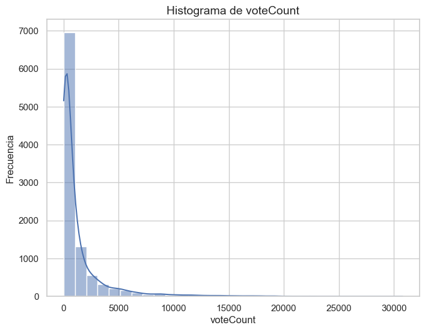

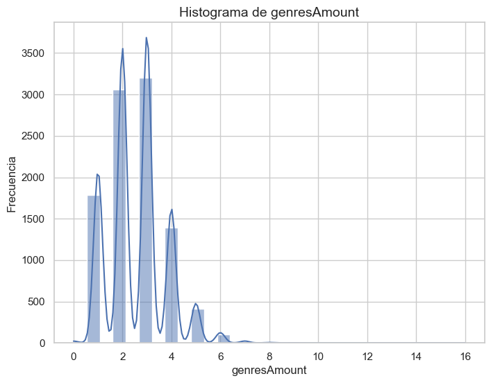

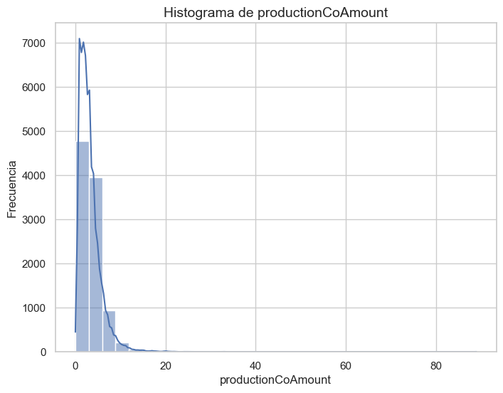

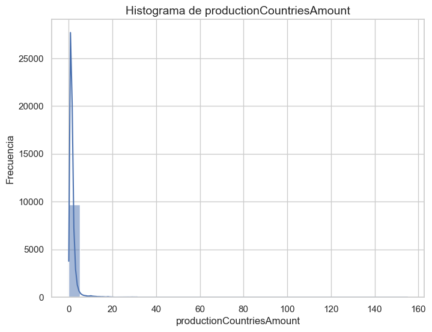

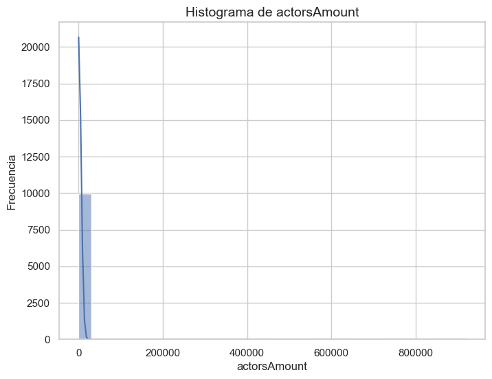

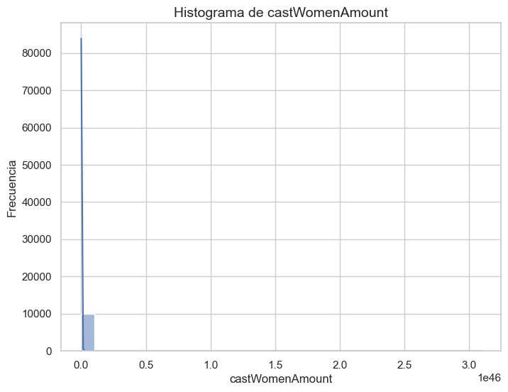

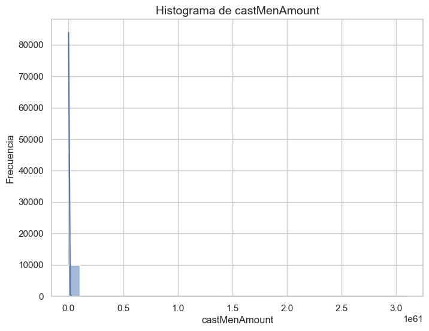

```python
variables_cuantitativas = [
    "budget", "revenue", "runtime", "voteAvg", "voteCount",
    "genresAmount", "productionCoAmount", "productionCountriesAmount",
    "actorsAmount", "castWomenAmount", "castMenAmount"
]
sns.set(style="whitegrid")

# Crear un gráfico para cada variable cuantitativa
for var in variables_cuantitativas:
    if var in df.columns:
        plt.figure(figsize=(8, 6))
        sns.histplot(df[var].dropna(), kde=True, bins=30)
        plt.title(f"Histograma de {var}", fontsize=14)
        plt.xlabel(var, fontsize=12)
        plt.ylabel('Frecuencia', fontsize=12)
        plt.show()
```

Con estos histogramas podemos concluir que runtime y voteAVG son las unicas que cumplen y tienen una distribucion normal mientas que todas las demas tienen la forma de sesgada hacia la derecha, excepto GenresAmount ya que tiene una distribucion Multimodal.

# Analisis de Variables Cualitativas

```python
variables_cualitativas = [
    "genre1", "genre2", "genre3", "homePage", "productionCompany",
    "productionCompanyCountry", "productionCountry", "video", "director",
    "actors", "actorsCharacter", "originalTitle", "title", "originalLanguage"
]

# Mostrar tablas
for var in variables_cualitativas:
    if var in df.columns:
        frecuencias = df[var].value_counts()
        tabla_frecuencias = frecuencias.to_frame(name="Frecuencia")
        tabla_estilizada = tabla_frecuencias.style.set_properties(**{'text-align': 'left'})
        display(tabla_frecuencias)
```

| genre1 | Frecuencia |
| --- | --- |
| Drama | 1803 |
| Comedy | 1519 |
| Action | 1518 |
| Horror | 901 |
| Animation | 811 |
| Thriller | 553 |
| Adventure | 542 |
| Crime | 376 |
| Family | 374 |
| Romance | 321 |
| Science Fiction | 305 |
| Documentary | 259 |
| Fantasy | 241 |
| Mystery | 104 |
| Music | 98 |
| War | 80 |
| Western | 61 |
| TV Movie | 46 |
| History | 35 |

| genre2 | Frecuencia |
| --- | --- |
| Drama | 1303 |
| Thriller | 930 |
| Comedy | 838 |
| Action | 716 |
| Adventure | 659 |
| Romance | 589 |
| Family | 454 |
| Crime | 453 |
| Animation | 425 |
| Horror | 386 |
| Fantasy | 356 |
| Science Fiction | 314 |
| Mystery | 251 |
| History | 208 |
| Music | 106 |
| TV Movie | 74 |
| War | 62 |
| Documentary | 36 |
| Western | 23 |

| genre3 | Frecuencia |
| --- | --- |
| Thriller | 581 |
| Drama | 332 |
| Romance | 299 |
| Science Fiction | 273 |
| Fantasy | 227 |
| ... | ... |
| Comedy\|Music\|Fantasy\|TV Movie | 1 |
| Comedy\|Drama\|War | 1 |
| Family\|Adventure\|Comedy\|Fantasy | 1 |
| Drama\|Fantasy\|Thriller | 1 |
| Action\|Comedy\|Fantasy | 1 |

618 rows × 1 columns

| homePage | Frecuencia |
| --- | --- |
| http://www.naruto-movie.com/ | 6 |
| http://www.thehungergames.movie/ | 4 |
| http://www.p3m.jp/ | 3 |
| http://www.kungfupanda.com/ | 3 |
| http://kizumonogatari-usa.com/ | 3 |
| ... | ... |
| http://www.lemonademouth.com | 1 |
| http://warnervideo.com/greenlanternemeraldknights/ | 1 |
| http://www.loversguide.com/ | 1 |
| http://dragontattoo.com/ | 1 |
| https://www.netflix.com/title/81425229 | 1 |

4125 rows × 1 columns

| productionCompany | Frecuencia |
| --- | --- |
| Paramount | 55 |
| Universal Pictures | 50 |
| Warner Bros. Pictures | 37 |
| Toei Animation | 34 |
| DreamWorks Animation | 33 |
| ... | ... |
| PSC\|Toho | 1 |
| Martini Films\|Paramount Famous Productions\|Pure Pictures Entertainment\|North by Northwest Entertainment | 1 |
| DreamWorks Home Entertainment | 1 |
| Omega Project\|AtomFilms\|Nemuru Otoko Seisaku Iinkai | 1 |
| Central Partnership\|KIT Film Studio | 1 |

8163 rows × 1 columns

| productionCompanyCountry | Frecuencia |
| --- | --- |
| US | 997 |
| US\|US | 792 |
| US\|US\|US | 452 |
| \|US | 292 |
| US\| | 265 |
| ... | ... |
| \|FR\|\|BE\|FR\|\|FR\|FR\|FR | 1 |
| GB\|DK\|\|SE\|DK\|GB\|IE\|IE | 1 |
| FR\|FR\|\|FR\|CA\|BE | 1 |
| US\|JP\|KR\|JP | 1 |
| CO\|CO | 1 |

2354 rows × 1 columns

| productionCountry | Frecuencia |
| --- | --- |
| United States of America | 4971 |
| Japan | 613 |
| United Kingdom\|United States of America | 339 |
| United Kingdom | 294 |
| Desconocido | 233 |
| ... | ... |
| United States of America\|Norway\|Sweden | 1 |
| Mexico\|Taiwan\|United States of America | 1 |
| Canada\|China\|Japan\|United States of America | 1 |
| China\|Canada\|United States of America\|United Kingdom | 1 |
| Ecuador | 1 |

880 rows × 1 columns

| video | Frecuencia |
| --- | --- |
| False | 9430 |
| True | 84 |

| director | Frecuencia |
| --- | --- |
| Desconocido | 74 |
| Steven Spielberg | 29 |
| Clint Eastwood | 28 |
| Ridley Scott | 23 |
| Steven Soderbergh | 19 |
| ... | ... |
| Kevin Farley | 1 |
| J�rgen Br�ning\|Kristian Petersen\|Todd Verow\|Maria Beatty\|Bruce LaBruce\|Courtney Trouble\|Manuela Kay\|�milie Jouvet | 1 |
| Doug Ellin | 1 |
| Ruairi Robinson | 1 |
| Alexandr Babaev | 1 |

5331 rows × 1 columns

| actors | Frecuencia |
| --- | --- |
| FALSE | 480 |
| TRUE | 6 |
| Kim Nam-joon\|Kim Seok-jin\|Min Yoon-gi\|Jung Ho-seok\|Park Ji-min\|Kim Tae-hyung\|Jeon Jung-kook | 3 |
| Minami Takayama\|Wakana Yamazaki\|Akira Kamiya\|Kappei Yamaguchi | 2 |
| Pablo Escobar | 2 |
| ... | ... |
| Chris Klein\|Heather Graham\|Orlando Jones\|Sally Field\|Richard Jenkins\|John Rothman\|Jack Plotnick\|Eddie Cibrian\|Mark Pellegrino\|Brent Hinkley\|Henry Cho\|Richard Riehle\|Brent Briscoe\|Ezra Buz… | 1 |
| James Marsden\|Gary Oldman\|Amy Smart\|Christopher Lloyd\|Chris Cooper\|Matthew Edison\|Paul Brogren\|Wayne Robson\|Michael J. Fox\|John Bourgeois\|Melyssa Ade\|Roz Michaels\|Amy Stewart\|Mark Lutz\|K… | 1 |
| Kenichi Matsuyama\|Narushi Fukuda\|Mayuko Fukuda\|Shingo Tsurumi\|Youki Kudoh\|Sei Hiraizumi\|Bokuzo Masana\|Yuta Kanai\|Megumi Sato\|Renji Ishibashi\|Kiyotaka Nanbara\|Masanobu Takashima\|Shunji Fuji… | 1 |
| Jay Chou\|Gwei Lun-mei\|Anthony Wong\|Alice Tzeng\|So Ming-Ming\|Huang Jun-Lang\|Devon Song\|Zhan Yu-Hao\|Chase Chang\|Aviis Zhong\|David Chang Hsun-Wei\|Funky Tu\|Tianze (Michael) Lin\|Chou Yao-Chung… | 1 |
| Shaffy Bello-Akinrimisi\|Funke Akindele\|Joke Silva\|Kate Henshaw-Nuttal\|Rahama Sadau\|Mawuli Gavor\|Beverly Naya\|Falz\|Linda Ejiofor\|Beverly Osu\|Broda Shaggi\|Williams Uzor Arukwe\|Zainab Balogun… | 1 |

9423 rows × 1 columns

| actorsCharacter | Frecuencia |
| --- | --- |
| \|\|\|\| | 17 |
| \|\|\|\|\| | 16 |
| \|\|\|\|\|\| | 16 |
| \|\|\| | 14 |
| \| | 13 |
| ... | ... |
| Balto (voice)\|Boris the Goose (voice)\|Jenna (voice)\|Steele the Sled Dog (voice)\|Muk and Luk (voice)\|Young Rosy (voice)\|Nikki (voice)\|Kaltag (voice)\|Star (voice)\|Dixie / Sylvie (voice)\|Grizzl… | 1 |
| Taku Morisaki (voice)\|Yutaka Matsuno (voice)\|Rikako Mutou (voice)\|Akiko Shimizu (voice)\|Yumi Kohama (voice)\|Okada (voice)\|Taku's Mother (voice)\|Girl (voice)\|Minarai (voice)\|Tadashi Yamao (voi… | 1 |
| Dr. Gluckman / Martian Guard #1 / President (voice)\|Martian Scientist / Court Attendant / Eyes At Gate (voice)\|Peep / Press Girl (voice)\|Commander Bristle / Martian Guard #3 (voice)\|Major Buzz Bli… | 1 |
| Sayra\|El Casper\|El Smiley\|Martha Marlene\|El Sol\|Leche/ Wounded Man\|Kimberly\|Resistol\|Horacio\|Lil' Mago\|El P�caro\|Clarissa\|Rosario\|Tia To�a\|Orlando\|Yamila\|Marero\|El Scarface | 1 |
| 922162 | 1 |

9796 rows × 1 columns

| originalTitle | Frecuencia |
| --- | --- |
| Pinocchio | 4 |
| Great Expectations | 3 |
| Escape Room | 3 |
| The Courier | 3 |
| Alice in Wonderland | 3 |
| ... | ... |
| Into the Sun | 1 |
| The Land Before Time X: The Great Longneck Migration | 1 |
| The Land Before Time XI: Invasion of the Tinysauruses | 1 |
| Dug's Special Mission | 1 |
| Row 19 | 1 |

9760 rows × 1 columns

| title | Frecuencia |
| --- | --- |
| Pinocchio | 4 |
| Cinderella | 4 |
| Carrie | 3 |
| The Courier | 3 |
| Awake | 3 |
| ... | ... |
| Blind Horizon | 1 |
| Chasing Papi | 1 |
| The Eye 2 | 1 |
| An Education | 1 |
| Row 19 | 1 |

9697 rows × 1 columns

| originalLanguage | Frecuencia |
| --- | --- |
| en | 7772 |
| ja | 644 |
| es | 425 |
| fr | 271 |
| ko | 167 |
| zh | 119 |
| it | 100 |
| de | 84 |
| cn | 80 |
| ru | 67 |
| pt | 43 |
| no | 28 |
| sv | 27 |
| hi | 27 |
| da | 27 |
| nl | 18 |
| th | 17 |
| pl | 15 |
| id | 12 |
| tr | 10 |
| fi | 8 |
| tl | 5 |
| te | 5 |
| sr | 4 |
| is | 4 |
| fa | 3 |
| ro | 2 |
| cs | 2 |
| el | 2 |
| uk | 2 |
| ms | 1 |
| ml | 1 |
| ta | 1 |
| la | 1 |
| he | 1 |
| ar | 1 |
| eu | 1 |
| bn | 1 |
| nb | 1 |
| ca | 1 |

# ¿Cuáles son las 10 películas que contaron con más presupuesto?

```python
df["budget"] = pd.to_numeric(df["budget"], errors="coerce")

peliculas_más_presupuesto = df.nlargest(10, "budget")

result = peliculas_más_presupuesto [["id", "title", "budget"]]

from IPython.display import display

display(result.style.set_properties(**{'text-align': 'left'}).set_caption("Top 10 Películas con Mayor Presupuesto"))
```

Top 10 Películas con Mayor Presupuesto

|  | id | title | budget |
| --- | --- | --- | --- |
| 716 | 1865 | Pirates of the Caribbean: On Stranger Tides | 380000000 |
| 4710 | 99861 | Avengers: Age of Ultron | 365000000 |
| 5952 | 299534 | Avengers: Endgame | 356000000 |
| 163 | 285 | Pirates of the Caribbean: At World's End | 300000000 |
| 4953 | 141052 | Justice League | 300000000 |
| 5953 | 299536 | Avengers: Infinity War | 300000000 |
| 607 | 1452 | Superman Returns | 270000000 |
| 3791 | 38757 | Tangled | 260000000 |
| 7134 | 420818 | The Lion King | 260000000 |
| 280 | 559 | Spider-Man 3 | 258000000 |

# ¿Cuál es la película que más votos tuvo?

```python
df["voteCount"] = pd.to_numeric(df["voteCount"], errors="coerce")

pelicula_más_votos = df.nlargest(1, "voteCount")

result = pelicula_más_votos[["id", "title", "voteCount"]]

display(result.style.set_properties(**{'text-align': 'left'}).set_caption("Película con Más Votos"))
```

Película con Más Votos

|  | id | title | voteCount |
| --- | --- | --- | --- |
| 3511 | 27205 | Inception | 30788 |

# ¿Cuántas películas se hicieron en cada año? ¿En qué año se hicieron más películas?

```
El año con más películas fue 2021 con 816 películas.
```

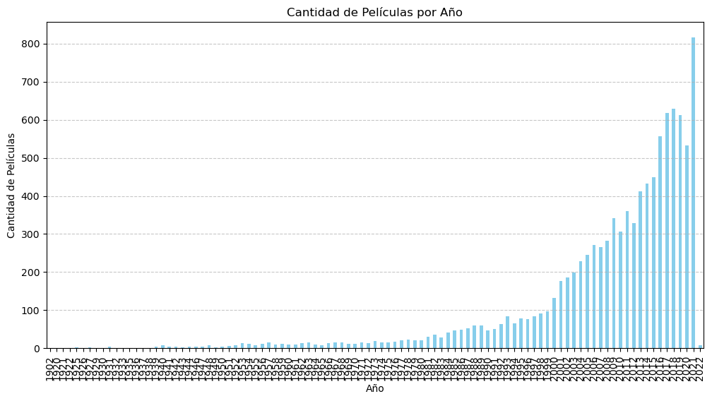

```python
df["releaseDate"] = pd.to_datetime(df["releaseDate"], errors="coerce")
df["año"] = df["releaseDate"].dt.year

peliculas_por_año = df["año"].value_counts().sort_index()
año_mas_peliculas = peliculas_por_año.idxmax()
cantidad_mas_peliculas = peliculas_por_año.max()
print(f"El año con más películas fue {año_mas_peliculas} con {cantidad_mas_peliculas} películas.")

# Gráfico de barras
plt.figure(figsize=(12,6))
peliculas_por_año.plot(kind="bar", color="skyblue")
plt.xlabel("Año")
plt.ylabel("Cantidad de Películas")
plt.title("Cantidad de Películas por Año")
plt.grid(axis="y", linestyle="--", alpha=0.7)
plt.show()
```

# ¿Las películas de qué genero principal obtuvieron mayores ganancias?

```python
df["revenue"] = pd.to_numeric(df["revenue"], errors="coerce")

ganancias_por_genero = df.groupby("genre1")["revenue"].sum().sort_values(ascending=False)
tabla_ganancias = ganancias_por_genero.reset_index()
tabla_ganancias.columns = ["Género", "Ganancias Totales"]
display(tabla_ganancias.style.set_properties(**{"text-align": "left"}).set_caption("Ganancias Totales por Género Principal"))
```

Ganancias Totales por Género Principal

|  | Género | Ganancias Totales |
| --- | --- | --- |
| 0 | Action | 140936671043 |
| 1 | Adventure | 86313291491 |
| 2 | Comedy | 72990070028 |
| 3 | Drama | 66415119599 |
| 4 | Animation | 44193668686 |
| 5 | Family | 27070466981 |
| 6 | Science Fiction | 25771021939 |
| 7 | Horror | 23483468549 |
| 8 | Fantasy | 22309474780 |
| 9 | Thriller | 17111426999 |
| 10 | Crime | 13764408000 |
| 11 | Romance | 9582546901 |
| 12 | War | 5151630856 |
| 13 | Mystery | 4640756330 |
| 14 | Music | 3493810817 |
| 15 | Western | 1843584942 |
| 16 | History | 1481950337 |
| 17 | Documentary | 352161888 |
| 18 | TV Movie | 0 |

# ¿Es posible que la cantidad de hombres y mujeres en el reparto influya en la popularidad y los ingresos de las películas?

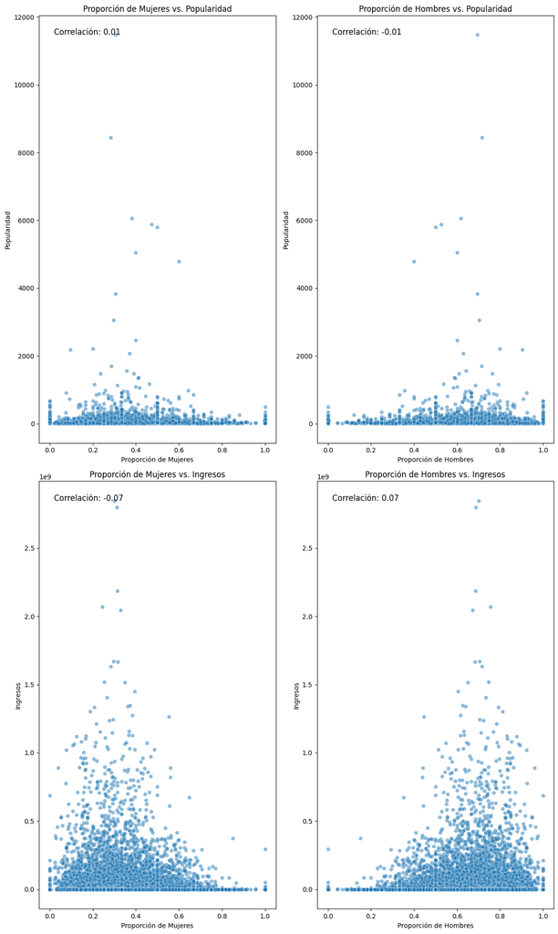

```python
peliculas_df_limpio = df.dropna(subset=['castWomenAmount', 'castMenAmount', 'popularity', 'revenue'])

peliculas_df_limpio['reparto_total'] = peliculas_df_limpio['castWomenAmount'] + peliculas_df_limpio['castMenAmount']
peliculas_df_limpio['proporcion_mujeres'] = peliculas_df_limpio['castWomenAmount'] / peliculas_df_limpio['reparto_total']
peliculas_df_limpio['proporcion_hombres'] = peliculas_df_limpio['castMenAmount'] / peliculas_df_limpio['reparto_total']

correlacion_mujeres_popularidad = peliculas_df_limpio[['proporcion_mujeres', 'popularity']].corr().iloc[0, 1]
correlacion_hombres_popularidad = peliculas_df_limpio[['proporcion_hombres', 'popularity']].corr().iloc[0, 1]
correlacion_mujeres_ingresos = peliculas_df_limpio[['proporcion_mujeres', 'revenue']].corr().iloc[0, 1]
correlacion_hombres_ingresos = peliculas_df_limpio[['proporcion_hombres', 'revenue']].corr().iloc[0, 1]

plt.figure(figsize=(12, 20))

# Gráfico 1: Proporción de mujeres vs. popularidad
plt.subplot(2, 2, 1)
sns.scatterplot(data=peliculas_df_limpio, x='proporcion_mujeres', y='popularity', alpha=0.5)
plt.text(0.02, max(peliculas_df_limpio['popularity']), f'Correlación: {correlacion_mujeres_popularidad:.2f}',
         fontsize=12)
plt.title('Proporción de Mujeres vs. Popularidad')
plt.xlabel('Proporción de Mujeres')
plt.ylabel('Popularidad')

# Gráfico 2: Proporción de hombres vs. popularidad
plt.subplot(2, 2, 2)
sns.scatterplot(data=peliculas_df_limpio, x='proporcion_hombres', y='popularity', alpha=0.5)
plt.text(0.02, max(peliculas_df_limpio['popularity']), f'Correlación: {correlacion_hombres_popularidad:.2f}',
         fontsize=12)
plt.title('Proporción de Hombres vs. Popularidad')
plt.xlabel('Proporción de Hombres')
plt.ylabel('Popularidad')

# Gráfico 3: Proporción de mujeres vs. ingresos
plt.subplot(2, 2, 3)
sns.scatterplot(data=peliculas_df_limpio, x='proporcion_mujeres', y='revenue', alpha=0.5)
plt.text(0.02, max(peliculas_df_limpio['revenue']), f'Correlación: {correlacion_mujeres_ingresos:.2f}',
         fontsize=12)
plt.title('Proporción de Mujeres vs. Ingresos')
plt.xlabel('Proporción de Mujeres')
plt.ylabel('Ingresos')

# Gráfico 4: Proporción de hombres vs. ingresos
plt.subplot(2, 2, 4)
sns.scatterplot(data=peliculas_df_limpio, x='proporcion_hombres', y='revenue', alpha=0.5)
plt.text(0.02, max(peliculas_df_limpio['revenue']), f'Correlación: {correlacion_hombres_ingresos:.2f}',
         fontsize=12)
plt.title('Proporción de Hombres vs. Ingresos')
plt.xlabel('Proporción de Hombres')
plt.ylabel('Ingresos')

plt.tight_layout()
plt.show()
```

Despues de los analisis podemos concluir que la correlacion entre la popularidad de una pelicula vs cantidad hombres o mujeres esten no estan relacionados y afecte significativamente, y en cuanto la a los ingresos es igual la proporcion de genero masculino y femenino no afecta a los ingresos de una producción.

# ¿Cómo se correlacionan los presupuestos con los ingresos? ¿Los altos presupuestos significan altos ingresos?

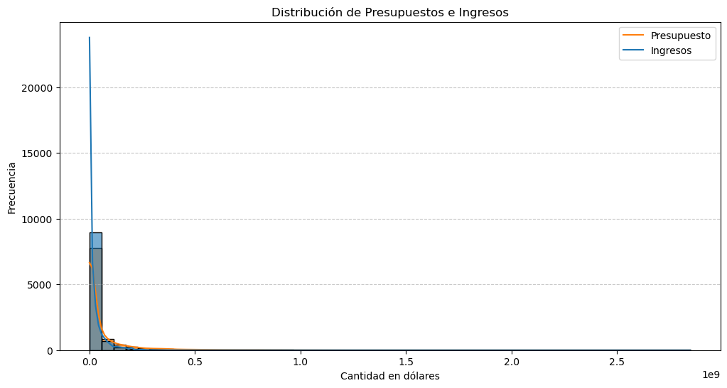

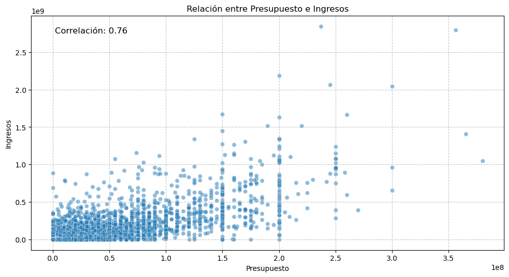

```python
df["budget"] = pd.to_numeric(df["budget"], errors="coerce")
df["revenue"] = pd.to_numeric(df["revenue"], errors="coerce")

#histograma de presupuestos e ingresos
plt.figure(figsize=(12,6))
sns.histplot(df[["budget", "revenue"]], bins=50, kde=True, alpha=0.6)
plt.xlabel("Cantidad en dólares")
plt.ylabel("Frecuencia")
plt.title("Distribución de Presupuestos e Ingresos")
plt.legend(["Presupuesto", "Ingresos"])
plt.grid(axis="y", linestyle="--", alpha=0.7)
plt.show()

#diagrama de dispersión entre presupuesto e ingresos
correlation = df["budget"].corr(df["revenue"])
plt.figure(figsize=(12,6))
sns.scatterplot(x=df["budget"], y=df["revenue"], alpha=0.5)
plt.xlabel("Presupuesto")
plt.ylabel("Ingresos")
plt.title("Relación entre Presupuesto e Ingresos")
plt.text(0.05, 0.95, f'Correlación: {correlation:.2f}', transform=plt.gca().transAxes, fontsize=12, verticalalignment='top')
plt.grid(True, linestyle="--", alpha=0.7)
plt.show()
```

Segun los resultados del histograma que se puede ver un sesgo hacia la derecha indica la mayoria de proyectos estan en el rango bajo- medio en terminos e ingresos y que son pocos los proyectos los cuales tienen un gran presupuesto y por lo tanto un gran ingreso. El diagrama de dispersion mostro una correlacion de 0.76 lo cual indica que hay una fuerte relacion entre los presupuestos e ingresos e indica que los proyectos con mayores presupuestos generan significativamente mas ingresos.

# ¿En qué meses se han visto los lanzamientos con mejores ingresos? ¿cuantas películas, en promedio, se han lanzado por mes?

```python
df["budget"] = pd.to_numeric(df["budget"], errors="coerce")
df["revenue"] = pd.to_numeric(df["revenue"], errors="coerce")
df["releaseDate"] = pd.to_datetime(df["releaseDate"], errors="coerce")
df["mes"] = df["releaseDate"].dt.month
ingresos_por_mes = df.groupby("mes")["revenue"].mean().sort_values(ascending=False)
peliculas_por_mes = df["mes"].value_counts().sort_index().mean()

tabla_ingresos = ingresos_por_mes.reset_index()
tabla_ingresos.columns = ["Mes", "Ingresos Promedio"]
display(tabla_ingresos.style.set_properties(**{"text-align": "left"}).set_caption("Ingresos Promedio por Mes"))

print(f"En promedio, se han lanzado {peliculas_por_mes:.2f} películas por mes.")
```

Ingresos Promedio por Mes

|  | Mes | Ingresos Promedio |
| --- | --- | --- |
| 0 | 6 | 94747108.225885 |
| 1 | 5 | 87845442.004298 |
| 2 | 7 | 76028696.397783 |
| 3 | 12 | 74358880.462032 |
| 4 | 11 | 71492112.452292 |
| 5 | 4 | 52595653.573276 |
| 6 | 3 | 51115941.964417 |
| 7 | 2 | 42908353.307365 |
| 8 | 10 | 38987332.024345 |
| 9 | 8 | 35970079.463308 |
| 10 | 1 | 33773690.825153 |
| 11 | 9 | 31928917.361446 |

```
En promedio, se han lanzado 833.33 películas por mes.
```

# ¿La popularidad del elenco está directamente correlacionada con el éxito de taquilla?

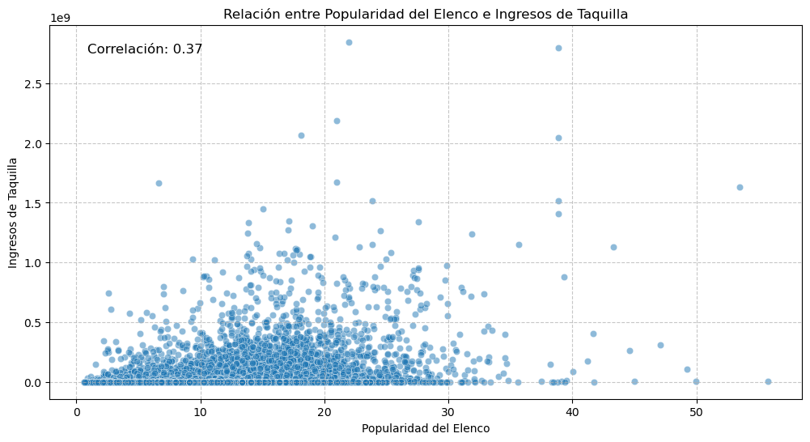

```python
popularity_columns = ["actorPopularity1", "actorPopularity2", "actorPopularity3", "actorPopularity4", "actorPopularity5"]
df[popularity_columns] = df[popularity_columns].apply(pd.to_numeric, errors="coerce")
df["castPopularity"] = df[popularity_columns].mean(axis=1)
df["revenue"] = pd.to_numeric(df["revenue"], errors="coerce")

#Diagrama de dispersión entre popularidad del elenco e ingresos
plt.figure(figsize=(12,6))
sns.scatterplot(x=df["castPopularity"], y=df["revenue"], alpha=0.5)
plt.xlabel("Popularidad del Elenco")
plt.ylabel("Ingresos de Taquilla")
plt.title("Relación entre Popularidad del Elenco e Ingresos de Taquilla")
correlacion = df["castPopularity"].corr(df["revenue"])
plt.text(0.05, 0.95, f'Correlación: {correlacion:.2f}', transform=plt.gca().transAxes, fontsize=12, verticalalignment='top')

plt.grid(True, linestyle="--", alpha=0.7)
plt.show()
```